# Lab 4

Javier Patrón

2023-05-08

# Lab 4 Assignment: Due May 9 at 11:59pm

Load the Libraries

```r
library(tidyverse)
library(rsample)
library(glmnet)
library(tidytext)
library(tidyverse)
library(tidymodels)
library(textrecipes)
library(discrim) # naive-bayes
library(janitor)
library(vip)
library(kableExtra)
urlfile ="https://raw.githubusercontent.com/MaRo406/EDS-231-text-sentiment/main/data/climbing_reports_model_dat.csv"

incidents_df <- readr::read_csv(url(urlfile))
```

### 1. Select a classification algorithm

For this lab we will use the **Decision Trees** model

Now we’ll split our data into training and test portions

```r
set.seed(123)

incidents_categorical <- incidents_df %>%
  mutate(fatal = factor(if_else(is.na(Deadly) , "non-fatal", "fatal")))

incidents_split <- initial_split(incidents_categorical)

incidents_train <- training(incidents_split)
incidents_test <- testing(incidents_split)
```

We use recipe() to specify the predictor and outcome variables and the data

```r
incidents_rec <- recipe(fatal ~ Text, data = incidents_train)
```

Next we add some familiar pre-processing steps on our Text variable: tokenize to word level, filter to the most common words, and calculate tf-idf.

```r
recipe <- incidents_rec %>%
  step_tokenize(Text) %>%
  step_tokenfilter(Text, max_tokens = 1000) %>%
  step_tfidf(Text) #new one from text recipes
```

### 2. Conduct an initial out-of-the-box model fit on the training data and prediction on the test data. Assess the performance of this initial model.

Set the Model Specs

```r
# Create model specification
tree_spec <- decision_tree(
  cost_complexity = tune(),
  tree_depth = tune(),
  min_n = tune()) |>
  set_engine("rpart") |>
  set_mode("classification")
```

Model Grid

```r
#Create a grid to be filled with your workflow
decision_tree_grid <- grid_regular(cost_complexity(),
                          tree_depth(),
                          min_n(),
                          levels = 5)
```

Model Work Flow

```r
# create the workflow for this decision tree
workflow_decisiontree <- workflow() |>
  add_recipe(recipe) |>
  add_model(tree_spec)
```

```r
#set up k-fold CV.
cross_validation <- incidents_train |>
  vfold_cv(v = 5)
```

```r
set.seed(123)
doParallel::registerDoParallel() # Run build trees in parallel

decision_tree_model <- tune_grid(
  workflow_decisiontree,
  resamples = cross_validation,
  grid = decision_tree_grid, # Select which grid will be used
  metrics = metric_set(accuracy)  # which combination is the best
)
```

Use autoplot() to examine how different parameter configurations relate to accuracy

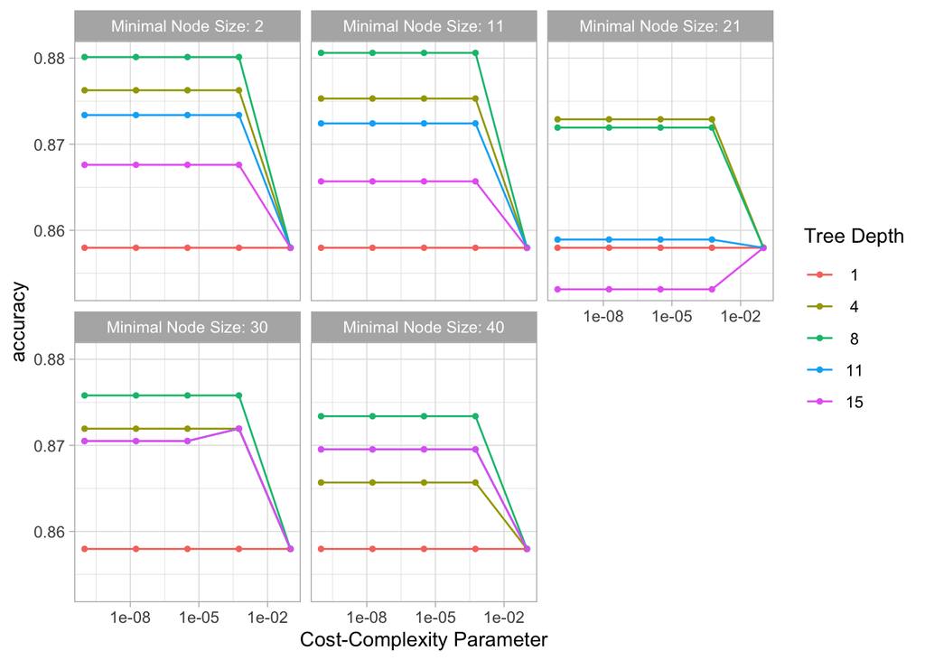

```r
autoplot(decision_tree_model) + theme_light()
```

### 3. Select the relevant hyper-parameters for your algorithm and tune your model.

Select the best hyperparrameters:

```r
# is you want to actually see the best values for accuracy
show_best(decision_tree_model)
```

```
## # A tibble: 5 × 9
##   cost_complexity tree_depth min_n .metric  .estimator  mean     n std_err
##             <dbl>      <int> <int> <chr>    <chr>      <dbl> <int>   <dbl>
## 1    0.0000000001          8    11 accuracy binary     0.881     5 0.00919
## 2    0.0000000178          8    11 accuracy binary     0.881     5 0.00919
## 3    0.00000316            8    11 accuracy binary     0.881     5 0.00919
## 4    0.000562              8    11 accuracy binary     0.881     5 0.00919
## 5    0.0000000001          8     2 accuracy binary     0.880     5 0.00786
## # ℹ 1 more variable: .config <chr>
```

```r
# model has to actually use one
select_best(decision_tree_model) # gives us the best hyper-parameters to use for our model
```

```
## # A tibble: 1 × 4
##   cost_complexity tree_depth min_n .config
##             <dbl>      <int> <int> <chr>
## 1    0.0000000001          8    11 Preprocessor1_Model036
```

We can finalize the model specification where we have replaced the tune functions with optimized values.

```r
final_tree <- finalize_workflow(workflow_decisiontree,
                             select_best(decision_tree_model))
```

### 4. Conduct a model fit using your newly tuned model specification. What are the terms most highly associated with non-fatal reports? What about fatal reports?

Lets do a last_fit

```r
final_tree_fit <- fit(final_tree,
                           incidents_train)
```

And finally, we can predict onto the testing data set.

```r
# Apply final_tree model to incidents_split dataset and collect metrics
decision_metric <- last_fit(final_tree, incidents_split) |>
  collect_metrics() %>%
  mutate(model = "Decision Tree") # Add a new column to the metrics with  "Decision Tree"

# Apply final_tree model to incidents_split dataset and collect predictions
decision_predictions <- last_fit(final_tree,
         incidents_split) |>
  collect_predictions()


# print table with kable
kable(decision_metric, align = "c") %>%
  kable_styling(full_width = FALSE, position = "center",
                bootstrap_options = "striped", font_size = 14)
```

| .metric | .estimator | .estimate | .config | model |
| --- | --- | --- | --- | --- |
| accuracy | binary | 0.9076479 | Preprocessor1_Model1 | Decision Tree |
| roc_auc | binary | 0.8438042 | Preprocessor1_Model1 | Decision Tree |

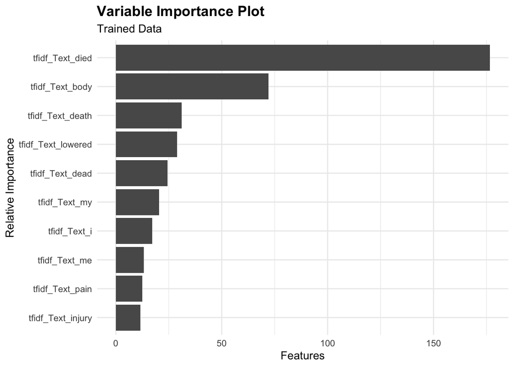

```r
# Fitting our final workflow
final_test <- final_tree_fit %>% fit(data = incidents_train)

final_test %>%
  extract_fit_parsnip() %>%
  vip(geom = "col") +
  theme_minimal() +
  labs(title = "Variable Importance Plot",
       subtitle = "Trained Data",
       x = "Relative Importance",
       y = "Features") +
  theme(plot.title = element_text(size = 14, face = "bold"))
```

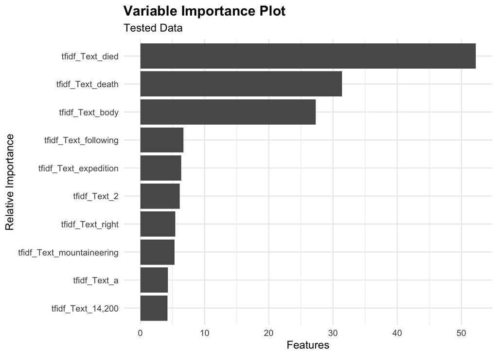

```r
# Fitting our final workflow
final_test <- final_tree_fit %>% fit(data = incidents_test)

final_test %>%
  extract_fit_parsnip() %>%
  vip(geom = "col") +
  theme_minimal() +
  labs(title = "Variable Importance Plot",
       subtitle = "Tested Data",
       x = "Relative Importance",
       y = "Features") +
  theme(plot.title = element_text(size = 14, face = "bold"))
```

```r
# # Generate ROC curve for the decision predictions indicating the probability of a text being fatal or non-fatal
# decision_predictions |>
#   group_by(id) |>
#   roc_curve(truth = fatal, .pred_fatal) |>
#   autoplot() +
#   labs(color = "Resamples",
#        title = "ROC for Fatal / Non-Fatal Reports ")
```

### 5. Predict fatality of the reports in the test set. Compare this prediction performance to that of the Naive Bayes and Lasso models.

Lets first recreate the same results we got from class for the Naive Bayer and the Lasso

```r
# recreate the Lasso metrics from class
lasso_metric <- data.frame(
  .metric = c("accuracy", "roc_auc"),
  .estimate = c(0.922, 0.958),
  model = c("Lasso", "Lasso"))

# recreate the Naive metrics from class
naive_metric <- data.frame(
  .metric = c("accuracy", "roc_auc"),
  .estimate = c(0.801, 0.736),
  model = c("Naive Bayes", "Naive Bayes"))

# wrangle the Decision Tree metrics from class
tidy_decision_metric <- data.frame(
  .metric = c("accuracy", "roc_auc"),
  .estimate = c(0.908, 0.844),
  model = c("Decision Tree", "Decision Tree"))
```

Create the final table with the results of the models

```r
# Creating a table with all the results
final_results <- bind_rows(naive_metric, lasso_metric, tidy_decision_metric)

final_table <- final_results |>
  select(model, .metric, .estimate) |>
  pivot_wider(names_from = .metric, values_from = .estimate) |>
  arrange(accuracy) |>
  mutate(model = fct_reorder(model, accuracy))
```

Create the final Table

```r
kable(final_table,
      padding = 1,
      digits = round(3),
      align = "c",
      format = "pipe",
      caption = "Model Comparision Summary")
```

Model Comparision Summary

| model | accuracy | roc_auc |
| --- | --- | --- |
| Naive Bayes | 0.801 | 0.736 |
| Decision Tree | 0.908 | 0.844 |
| Lasso | 0.922 | 0.958 |

Create the final graph comparison

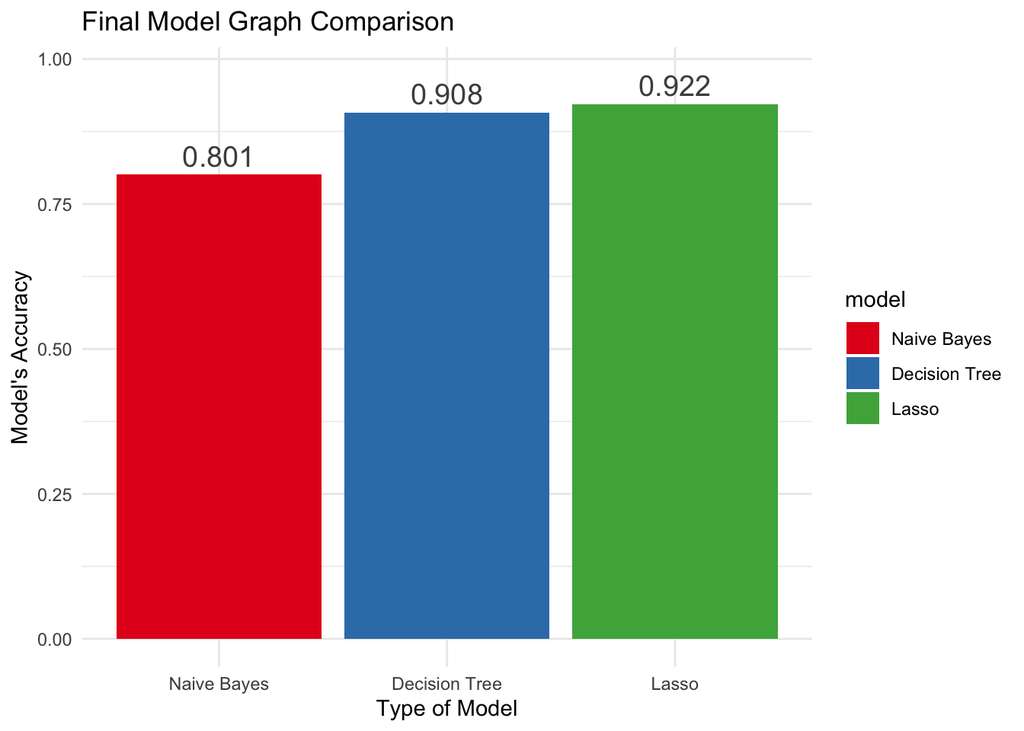

```r
final_table %>%
  ggplot(aes(x = model, y = accuracy, fill = model)) +
  geom_col() +
  labs(title = "Final Model Graph Comparison",
       x = "Type of Model",
       y = "Model's Accuracy") +
  geom_text(size = 5, aes(label = round(accuracy, 3), y = accuracy + 0.05),
            vjust = 1, color = "gray30") +
  scale_fill_brewer(palette = "Set1") +
  theme_minimal()
```